# Machine Learning Final Project

## BACKGROUND

Using devices such as Jawbone Up, Nike FuelBand, and Fitbit it is now possible to collect a large amount of data about personal activity relatively inexpensively. These type of devices are part of the quantified self movement - a group of enthusiasts who take measurements about themselves regularly to improve their health, to find patterns in their behavior, or because they are tech geeks. One thing that people regularly do is quantify how much of a particular activity they do, but they rarely quantify how well they do it. In this project, the goal will be to use data from accelerometers on the belt, forearm, arm, and dumbell of 6 participants. They were asked to perform barbell lifts correctly and incorrectly in 5 different ways (labeled A,B,C,D and E). We`ll build a model to predict in which manner they were doing the exercice based on variables from the main dataset.

## UNDERSTANDING THE PROBLEM

As the values to predict are categorical or “factors” in R terms, this is a classification problem.

The outcome of this report will explain:

- How the classification model was built.
- How cross validation was used.
- What is the expected out of sample error.
- Why we made each choice.

## EXPLORATORY WORK

```r
library(caret)
library(dplyr)
library(MASS)
library(randomForest)
library(rpart)
library(rpart.plot)
library(ggplot2)
```

Our dataset’s dimensions are the following

Training set

```
## [1] 19622   160
```

Test set

```
## [1]  20 160
```

Let’s have a further look at the variables

Training set variables

```
##   [1] "X"                        "user_name"
##   [3] "raw_timestamp_part_1"     "raw_timestamp_part_2"
##   [5] "cvtd_timestamp"           "new_window"
##   [7] "num_window"               "roll_belt"
##   [9] "pitch_belt"               "yaw_belt"
##  [11] "total_accel_belt"         "kurtosis_roll_belt"
##  [13] "kurtosis_picth_belt"      "kurtosis_yaw_belt"
##  [15] "skewness_roll_belt"       "skewness_roll_belt.1"
##  [17] "skewness_yaw_belt"        "max_roll_belt"
##  [19] "max_picth_belt"           "max_yaw_belt"
##  [21] "min_roll_belt"            "min_pitch_belt"
##  [23] "min_yaw_belt"             "amplitude_roll_belt"
##  [25] "amplitude_pitch_belt"     "amplitude_yaw_belt"
##  [27] "var_total_accel_belt"     "avg_roll_belt"
##  [29] "stddev_roll_belt"         "var_roll_belt"
```

[output cut: 65 more lines]

To get a glance on the type of information that each variable provides, let’s make a summary of them

```
##        X            user_name    raw_timestamp_part_1 raw_timestamp_part_2
##  Min.   :    1   adelmo  :3892   Min.   :1.322e+09    Min.   :   294
##  1st Qu.: 4906   carlitos:3112   1st Qu.:1.323e+09    1st Qu.:252912
##  Median : 9812   charles :3536   Median :1.323e+09    Median :496380
##  Mean   : 9812   eurico  :3070   Mean   :1.323e+09    Mean   :500656
##  3rd Qu.:14717   jeremy  :3402   3rd Qu.:1.323e+09    3rd Qu.:751891
##  Max.   :19622   pedro   :2610   Max.   :1.323e+09    Max.   :998801
##
##           cvtd_timestamp  new_window    num_window      roll_belt
##  28/11/2011 14:14: 1498   no :19216   Min.   :  1.0   Min.   :-28.90
##  05/12/2011 11:24: 1497   yes:  406   1st Qu.:222.0   1st Qu.:  1.10
##  30/11/2011 17:11: 1440               Median :424.0   Median :113.00
##  05/12/2011 11:25: 1425               Mean   :430.6   Mean   : 64.41
##  02/12/2011 14:57: 1380               3rd Qu.:644.0   3rd Qu.:123.00
##  02/12/2011 13:34: 1375               Max.   :864.0   Max.   :162.00
##  (Other)         :11007
##    pitch_belt          yaw_belt       total_accel_belt kurtosis_roll_belt
##  Min.   :-55.8000   Min.   :-180.00   Min.   : 0.00             :19216
##  1st Qu.:  1.7600   1st Qu.: -88.30   1st Qu.: 3.00    #DIV/0!  :   10
##  Median :  5.2800   Median : -13.00   Median :17.00    -1.908453:    2
##  Mean   :  0.3053   Mean   : -11.21   Mean   :11.31    -0.016850:    1
##  3rd Qu.: 14.9000   3rd Qu.:  12.90   3rd Qu.:18.00    -0.021024:    1
##  Max.   : 60.3000   Max.   : 179.00   Max.   :29.00    -0.025513:    1
##                                                        (Other)  :  391
##  kurtosis_picth_belt kurtosis_yaw_belt skewness_roll_belt
##           :19216            :19216              :19216
##  #DIV/0!  :   32     #DIV/0!:  406     #DIV/0!  :    9
##  47.000000:    4                       0.000000 :    4
##  -0.150950:    3                       0.422463 :    2
##  -0.684748:    3                       -0.003095:    1
##  -1.750749:    3                       -0.010002:    1
##  (Other)  :  361                       (Other)  :  389
##  skewness_roll_belt.1 skewness_yaw_belt max_roll_belt     max_picth_belt
##           :19216             :19216     Min.   :-94.300   Min.   : 3.00
##  #DIV/0!  :   32      #DIV/0!:  406     1st Qu.:-88.000   1st Qu.: 5.00
##  0.000000 :    4                        Median : -5.100   Median :18.00
##  -2.156553:    3                        Mean   : -6.667   Mean   :12.92
##  -3.072669:    3                        3rd Qu.: 18.500   3rd Qu.:19.00
##  -6.324555:    3                        Max.   :180.000   Max.   :30.00
##  (Other)  :  361                        NA's   :19216     NA's   :19216
```

[output cut: 313 more lines]

```
##  Min.   :-446.00   Min.   :-1280.0   Min.   :-896.0   Min.   :-973.0
##  1st Qu.:-182.00   1st Qu.: -616.0   1st Qu.:   2.0   1st Qu.: 191.0
##  Median : -39.00   Median : -378.0   Median : 591.0   Median : 511.0
##  Mean   : -55.29   Mean   : -312.6   Mean   : 380.1   Mean   : 393.6
##  3rd Qu.:  26.00   3rd Qu.:  -73.0   3rd Qu.: 737.0   3rd Qu.: 653.0
##  Max.   : 291.00   Max.   :  672.0   Max.   :1480.0   Max.   :1090.0
##
##  classe
##  A:5580
##  B:3797
##  C:3422
##  D:3216
##  E:3607
##
##
```

From this step it becomes clear that not every variable appear to have potentially strong predictive power. The first group of variables provide no useful information for predicting activities. Basically from X to new_window

Apart from that, there are a lot of variables with NAs and #DIV/0! errors, thus making them irrelevant to use to build a predictive model

## DATA CLEANING

Before using the datasets to train models, we need to get rid of irrelevant and incomplete data discovered in the previous analysis.

This basically means not using variables with NA variables and observations with errors, apart from getting rid of variables containing complete data that do not provide useful insight for classification of activities, such as the first group of variables

```r
#Getting rid of irrelevant features

training_set_first = read.csv("./training.csv")
test_set_first = read.csv("./test.csv")

training_set = training_set_first
test_set = test_set_first

training_set = dplyr::select(training_set,-(X:new_window))
test_set = dplyr::select(test_set,-(X:new_window))

# Getting rid of features with NAs

training_set = training_set[ , colSums(is.na(training_set)) == 0]
test_set = test_set[ , colSums(is.na(test_set)) == 0]

# Getting rid of factor variables, except for the activities, as they are not present
# in the test set and after further examination,hey add no useful information


activities <- training_set$classe
clean_training = training_set[,-grep("factor",sapply(training_set,class))]

clean_training$classe <- activities
```

## DESIGN STUDY

In order to estimate out of sample error and to perform cross validation, and considering our test set does not contain a classe variable, a further partion of the main training set into a pure training and a test set will be necessary. The model will be trained using pure training data, and will be validated, with the corresponding error estimates, using the test set.

We’ll use random sampling from the main training set to make sure no extra bias is introduced in the analysis by the selection itself. An 80 (train)/20 (test) proportion will be used. Too much data devoted to validation will leave us with a smaller sample to train our model, resulting in higher bias on the estimates. Conversely, too much data devoted to training the model increases the risk of ending up with a model that overfits its training data and performs poorly on unseen sets.

```r
# Creating partitions for cross validation and estimation of out of sample
# error, as our test data does not include an activity label to use that
# dataset for error estimating purposes

training_obs = createDataPartition(clean_training$classe, p = 0.8,list = FALSE)
pure_training = clean_training[training_obs,]
testing_dataset = clean_training[-training_obs,]
```

## BUILDING MODELS

Considering our problem is of classification and our variable number is moderate, at first glance, tree based algorithms could be a nice choice. Firstly, they are more interpretable (as getting insight from the problem is as important as getting a precise prediction), they evaluate what variables are more important for splitting the data in homogeneuos groups and can decide to not use variables that provides little information to make a decision.

Among them, rpart trees are among the most interpretable. That’s why this is the first model we try to fit

### RPart tree

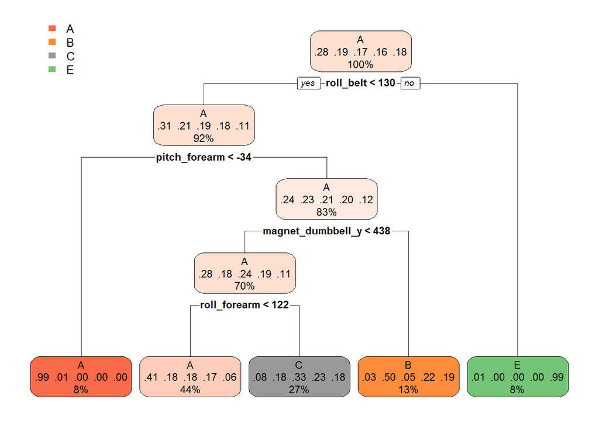

```
## Confusion Matrix and Statistics
##
##           Reference
## Prediction    A    B    C    D    E
##          A 1009  307  323  268  103
##          B   16  259   16  117   95
##          C   91  193  345  258  200
##          D    0    0    0    0    0
##          E    0    0    0    0  323
##
## Overall Statistics
##
##                Accuracy : 0.4935
##                  95% CI : (0.4777, 0.5093)
##     No Information Rate : 0.2845
##     P-Value [Acc > NIR] : < 2.2e-16
##
##                   Kappa : 0.3388
##  Mcnemar's Test P-Value : NA
##
## Statistics by Class:
##
##                      Class: A Class: B Class: C Class: D Class: E
## Sensitivity            0.9041  0.34124  0.50439   0.0000  0.44799
## Specificity            0.6434  0.92288  0.77092   1.0000  1.00000
## Pos Pred Value         0.5020  0.51491  0.31739      NaN  1.00000
## Neg Pred Value         0.9441  0.85380  0.88047   0.8361  0.88944
## Prevalence             0.2845  0.19347  0.17436   0.1639  0.18379
## Detection Rate         0.2572  0.06602  0.08794   0.0000  0.08233
## Detection Prevalence   0.5124  0.12822  0.27708   0.0000  0.08233
## Balanced Accuracy      0.7738  0.63206  0.63765   0.5000  0.72399
```

### Random Forest

Every algorithm based on Bagging is proven to produce models with similar bias than their non-bagging based counterparts but reduced variance. In this particular case, the random forest algorithm grows trees using random combinations of observation and variables and then averaging the results to build the final model.

When tried on our training set and using our validation set to test for accuracy, these are the results

```
## Confusion Matrix and Statistics
##
##           Reference
## Prediction    A    B    C    D    E
##          A 1116    0    0    0    0
##          B    0  759    0    0    0
##          C    0    0  684    2    0
##          D    0    0    0  641    1
##          E    0    0    0    0  720
##
## Overall Statistics
##
##                Accuracy : 0.9992
##                  95% CI : (0.9978, 0.9998)
##     No Information Rate : 0.2845
##     P-Value [Acc > NIR] : < 2.2e-16
##
##                   Kappa : 0.999
##  Mcnemar's Test P-Value : NA
##
## Statistics by Class:
##
##                      Class: A Class: B Class: C Class: D Class: E
## Sensitivity            1.0000   1.0000   1.0000   0.9969   0.9986
## Specificity            1.0000   1.0000   0.9994   0.9997   1.0000
## Pos Pred Value         1.0000   1.0000   0.9971   0.9984   1.0000
## Neg Pred Value         1.0000   1.0000   1.0000   0.9994   0.9997
## Prevalence             0.2845   0.1935   0.1744   0.1639   0.1838
## Detection Rate         0.2845   0.1935   0.1744   0.1634   0.1835
## Detection Prevalence   0.2845   0.1935   0.1749   0.1637   0.1835
## Balanced Accuracy      1.0000   1.0000   0.9997   0.9983   0.9993
```

From the Confusion Matrix results, the Random Forest model performs very good, with both Accuracty and Kappa levels above 99%

Typically, in order to get better accuracy we could Ensamble both of our models and average their predictions, at the expense of interpretability. In this case, such a procedure does not appear to be needed, given the great predictive power of our last model.

#### Code for building the models

```r
testing_dataset = clean_training[-training_obs,]

# Model creation

model_rf = randomForest(classe ~ .,na.action = na.omit,data = pure_training)
model_rpart = train(classe ~ .,na.action = na.omit,data = pure_training,method = "rpart")

# Predicting with both models

predict_rf = predict(model_rf,newdata = testing_dataset)
predict_rpart = predict(model_rpart,newdata = testing_dataset)

# Evaluating errors

confmatrix_rf = confusionMatrix(predict_rf,reference = testing_dataset$classe)
confmatrix_rpart = confusionMatrix(predict_rpart,reference = testing_dataset$classe)
```

## MODEL SELECTION

### Using model to predict class in test cases

```
##  1  2  3  4  5  6  7  8  9 10 11 12 13 14 15 16 17 18 19 20
##  B  A  B  A  A  E  D  B  A  A  B  C  B  A  E  E  A  B  B  B
## Levels: A B C D E
```